# cars-and-street-crime_17th-july

**Exploring the effect of motor traffic on street crime**

Jose Pina-Sánchez & Toby Davies

## Introduction

- Motor traffic harms quality of life

  – affecting pollution, noise, exercise, social ties, …

  – and, obviously, car accidents and other motoring offences
- But what about other forms of street crime?

  – paradoxically, only a couple of studies have looked into it

## Hypothetical mechanisms

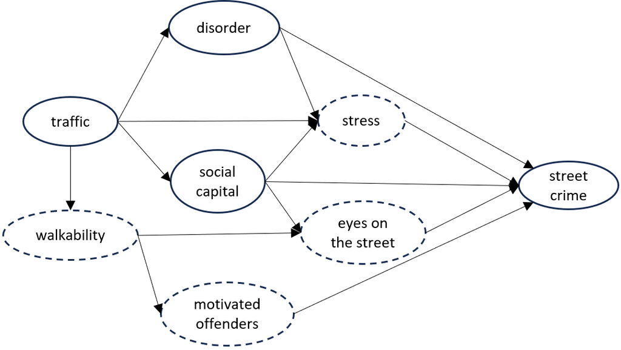

# Analytical Strategy

## Longitudinal data

- Three waves from *Understanding Society* (2012, 2015 and 2018)

  – necessary to observe changes in neighbourhoods across time

  – remove those who moved to a different address

  – lots of attrition (about 60% missing in 2015 and 90% in 2018)

  – adjusted using multiple imputation
- Subjective measures of motor traffic and perceptions of crime

  – derived from the interviewer and the interviewee

  – which eliminates methods effects

## Fixed effects models

- We model the within-person change across time

  – control for average change in perceptions of crime across time
- We focus on the total effect of traffic on crime

  – and indirect effects through social capital and disorder

# Findings

- Total effects

  – when a neighbourhood goes from “non-heavy traffic” to “heavy traffic”…

  – we estimate an 8.6%, 6.4% and 6.9% increase in perceptions of vandalism, theft, and violence
- Mediating effects

  – traffic leads to perceptions of disorder (graffity, litter, and boarded houses)

  – and undermines social capital (whether neighbours are perceived to help each other)

  – these in turn increase perceptions of crime

# Robustness Checks

## Confounding bias

- We cannot anticipate an obvious time-changing confounder

  – we cannot rule it out either
- A “small” confounder could render our findings non-significant

  – our robustness values range from 2.8% to 4%

## Measurement error

- Interviewee’s records of ‘heavy traffic’ are noisy

  – can see this as classical measurement error
- Attenuation bias (roughly) proportional to the errors

  – e.g. a reliability of 0.8, attenuates our estimates by 1.2

# Discussion

## Theory and policy implications

- Motor traffic appears to have a causal effect on street crime

  – to some extent mediated through disorder and social capital
- Reducing car dependency is even more beneficial than we thought
- Crime prevention policy needs to recognise the criminogenic effect of motor traffic

  – *Secured by Design HOMES* should be reconsidered

  – e.g. culs-de-sac might be less prone to burglary but they force higher crime elsewhere by encouraging driving